## IMS Curriculum survey

### September 11, 2018

### Overview

As part of the response for the AQAD implementation plan for SMAST/IMS, a survey was distributed to IMS faculty to obtain information on course offerings, with a goal to provide resources for students on timing of course offerings and availability, and perform gap analysis on the SMAST curriculum.

### Survey questions

Summary of questions asked:

```
##  [1] "Timestamp"
##  [2] "Course Prefix & Number"
##  [3] "Course Title"
##  [4] "Instructor"
##  [5] "Number of Credits"
##  [6] "Please provide a 1-paragraph summary of course topics and learning outcomes (e.g. paste from syllabus or FAR)"
##  [7] "When offered?"
##  [8] "Last offered (Semester & Year)"
##  [9] "Where offered?"
## [10] "Is the course cross-listed with another department or an undergraduate course?"
## [11] "Distance learning available?"
## [12] "What is the learning approach?"
## [13] "Satisfies Core Course Requirement?"
## [14] "Could this be listed as meeting a core course requirement?"
## [15] "What are the prerequisites for this class?"
## [16] "When in their program do students typically take this class?"
## [17] "Further notes / comments about this class not addressed above"
```

### Analysis of survey results

A total of

```
## [1] 32
```

responses were submitted. This does not cover all the current offerings within our curriculum.

Summaries of some of the responses are provided below:

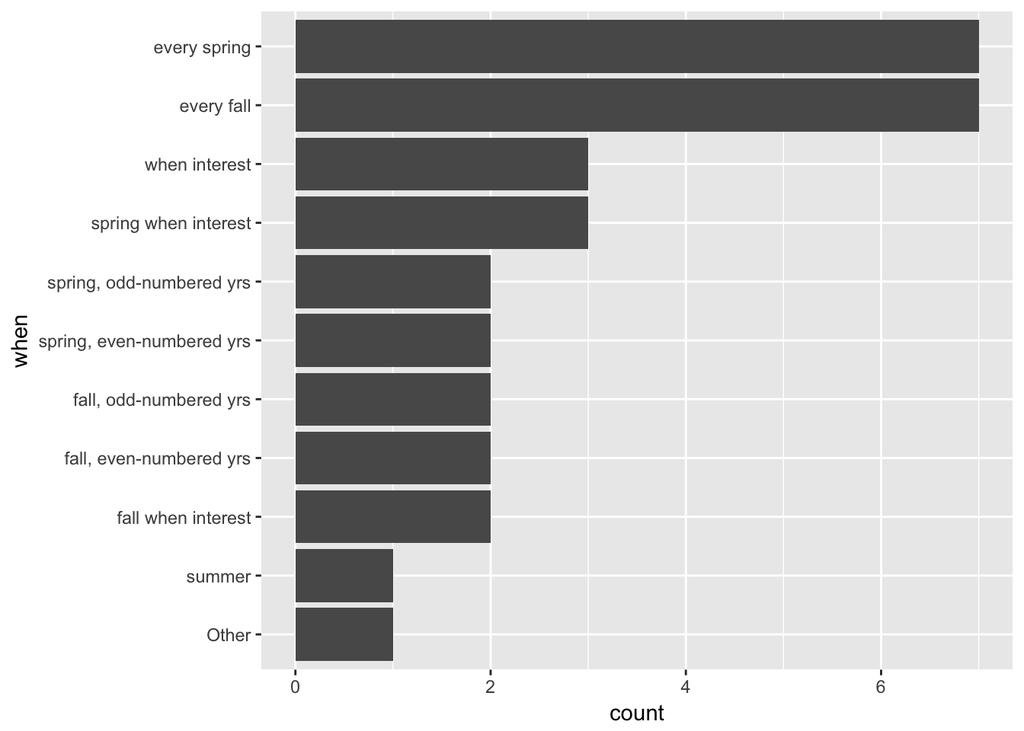

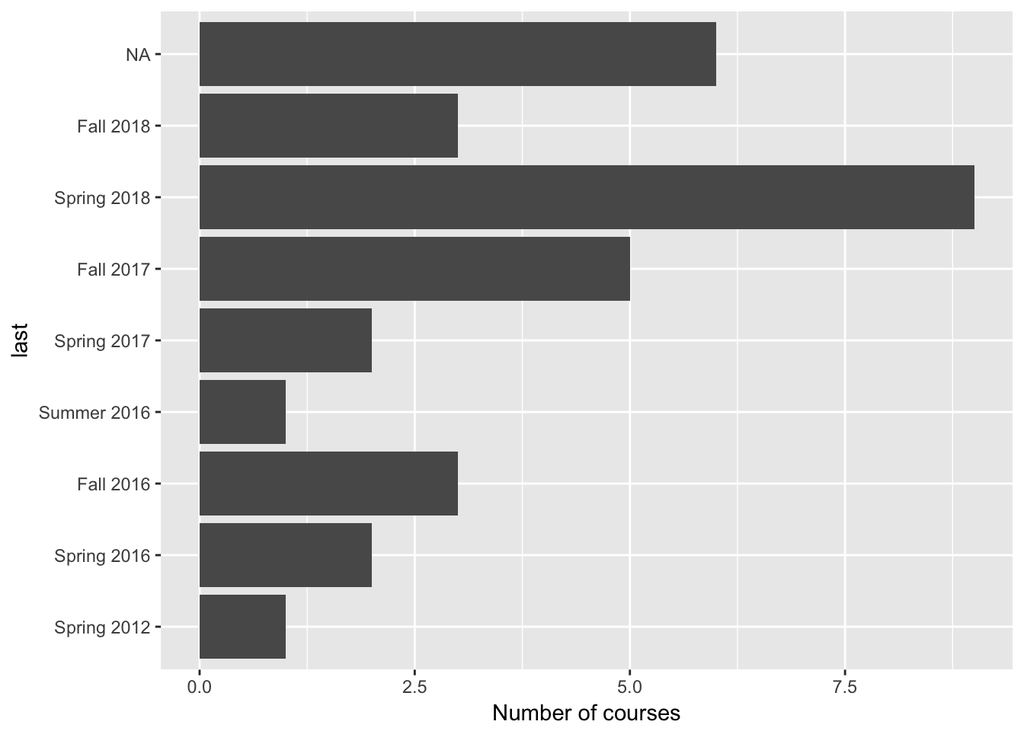

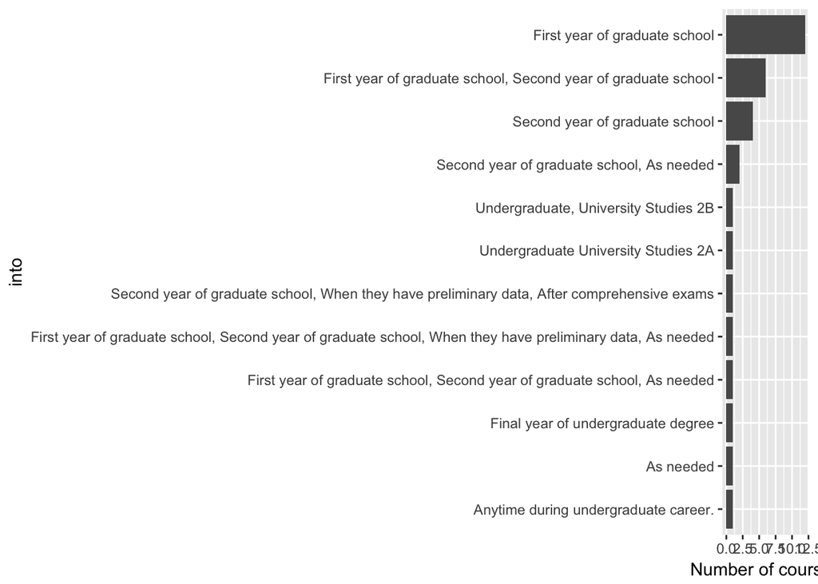

A large number of graduate courses are intended to be offered every academic year, and most of the courses included in the survey results are active (taught within the last 2-3 academic years). There is a fair amount of flexibility in the targeting of courses to where students are during their program, though a substantial number of courses are intended to be taken in the first year of study. This may be incompatible with courseloads, but further analysis is needed (GF to remove core courses from this last panel).

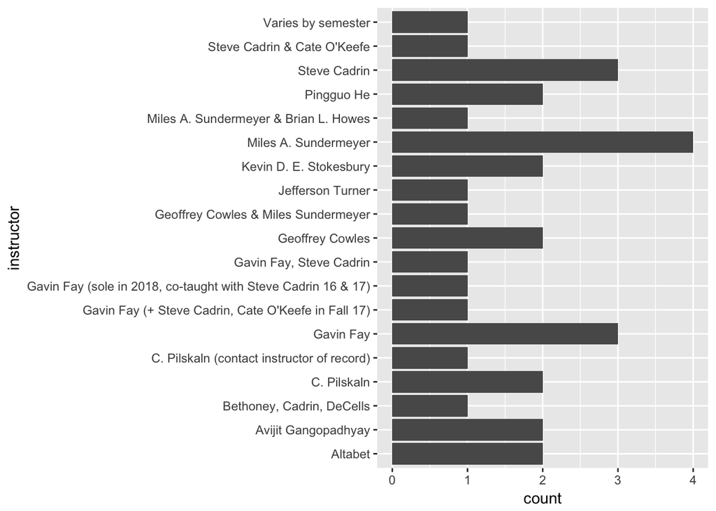

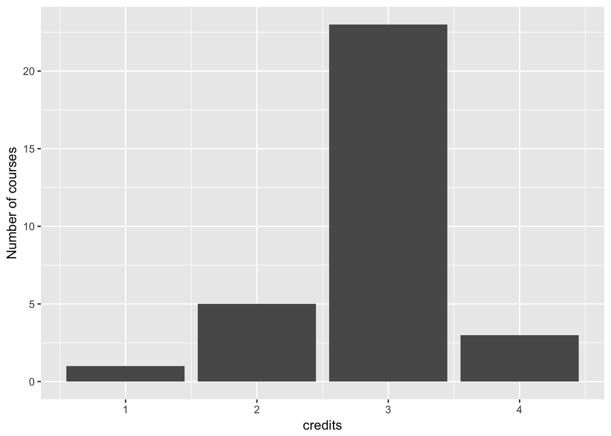

Most courses are offered for 3 credits. 4 credit courses are generally those which include a lab section. 1 credit classes include the required graduate seminars.

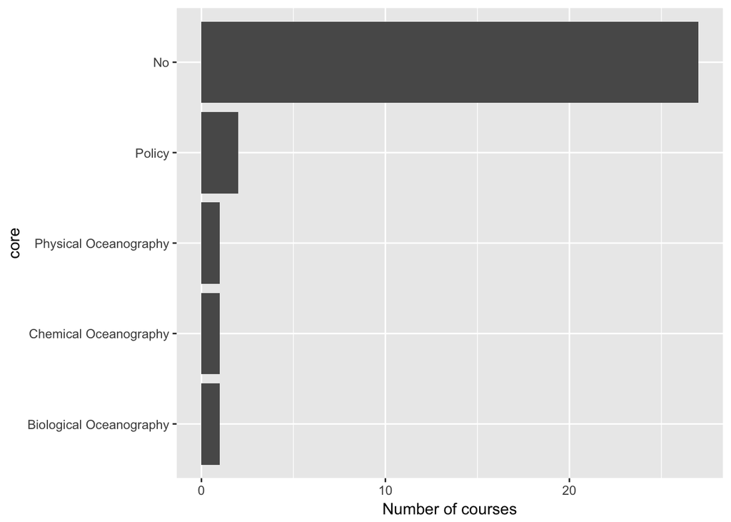

### Resources for students

A timetable of course names, instructors, when offered, and whether the courses meet core course requirements would be a useful resource for the SMAST & IMS websites to help both students and advisors with degree planning. A suggested format is provided below (though note this is incomplete due to only using survey results).  
An additional useful resource would be suggested possible sequence/schedules of courses for students in the PSM / MS / and doctoral degree programs. Note that these would be to give prospective applicants a flavor of what coursework could look like within the program, rather than being prescriptive. Individual faculty will have their own ‘preferred’ menu of courses for students working in their research groups and areas of specialty. An additional list of courses in other departments and campuses that are available and relevant to IMS students could be provided or pointed to.  
There has been some attempt to assign course numbers by topic and to separate 500 and 600 level courses. A recommendation moving forward would be to be stricter about this, perhaps an assignment of number ranges for certain course sequences / topics could be proposed. There have been a large number of recently taught special topics courses (e.g. 580) that are becoming a normal part of the regular curriculum. Instructors for these courses are encouraged to request a proper number to have these courses listed as their own course. Such a move will help to solidify the transparency of course offerings within the various IMS programs.

| code | title | instructor | credits | when | last | core |
| --- | --- | --- | --- | --- | --- | --- |
| MAR 530 | Ecosystem Based Fisheries Management | Gavin Fay | 3.00 | spring, odd-numbered yrs | Spring 2017 | Policy |
| MAR 555 | Introductory Physical Oceanography | Geoffrey Cowles & Miles Sundermeyer | 3.00 | every fall | Fall 2017 | Physical Oceanography |
| BIO/MAR 545 | Biological Oceanography | Jefferson Turner | 4.00 | every spring | Spring 2018 | Biological Oceanography |
| MAR 510 | Introduction to Chemical Oceanography | Altabet | 3.00 | every spring | Spring 2018 | Chemical Oceanography |
| MAR 527 | Fisheries Management | Steve Cadrin | 3.00 | fall, odd-numbered yrs |  | Policy |
| MAR 580 | Science Communication for Research Scientists | Gavin Fay (+ Steve Cadrin, Cate O’Keefe in Fall 17) | 3.00 | every fall | Fall 2017 | No |
| MAR 580 | Advanced Population Modeling for Management of Living Marine Resources | Gavin Fay, Steve Cadrin | 3.00 | fall, odd-numbered yrs | Fall 2017 | No |
| MAR 536 | Biological Statistics II | Gavin Fay (sole in 2018, co-taught with Steve Cadrin 16 & 17) | 4.00 | every spring | Spring 2018 | No |
| MAR 700 | Graduate Seminar in Fisheries Oceanography | Varies by semester | 1.00 | Other | Spring 2018 | No |
| MAR 595 | Bayesian Statistics and Hierarchical Modeling for Ecology | Gavin Fay | 3.00 | fall, even-numbered yrs | Fall 2018 | No |
| MAR 580 | Models for Marine Ecosystem Based Management | Gavin Fay | 3.00 | spring, even-numbered yrs | Spring 2016 | No |
| MAR 514 | Quantitative Methods for Marine Applications | Geoffrey Cowles | 3.00 | fall when interest | Fall 2016 | No |
| MAR 524 | Ecosystem Modeling | Geoffrey Cowles | 3.00 | spring when interest | Spring 2012 | No |
| MAR 515 | Geological Oceanography | C. Pilskaln | 3.00 | every fall | Fall 2017 | No |
| MAR 599 | Special Topics: Aquatic biogeochemical particle flux dynamics | C. Pilskaln | 2.00 | spring when interest | Spring 2018 | No |
| MAR 499 | SMAST Summer Research Internship for Undergraduates | C. Pilskaln (contact instructor of record) | 2.00 | summer | Summer 2016 | No |
| MAR 580 | Field Methods for Fisheries Research | Bethoney, Cadrin, DeCells | 2.00 | when interest | Spring 2018 | No |
| MAR 645 | Ocean Circulation and Modeling | Avijit Gangopadhyay | 2.00 | every fall | Fall 2018 | No |
| MAR 655 | Ocean Atmosphere Dynamics | Avijit Gangopadhyay | 2.00 | every spring | Spring 2016 | No |
| MAR 540 | Introductory Fisheries Science | Kevin D. E. Stokesbury | 3.00 | every fall | Fall 2017 | No |
| MAR 675 | Scientific Writing | Kevin D. E. Stokesbury | 3.00 | every spring | Spring 2018 | No |
| MAR 660 | Coastal Physical Oceanography | Miles A. Sundermeyer | 3.00 | when interest |  | No |
| MAR 550 | Laboratory in Oceanography - Data and Methods | Miles A. Sundermeyer | 3.00 | when interest | Fall 2016 | No |
| MAR 620 | Case Studies in Estuarine Dynamics | Miles A. Sundermeyer & Brian L. Howes | 4.00 | spring when interest | Spring 2017 | No |
| MAR105 | Introductory Ocean Science - Online | Miles A. Sundermeyer | 3.00 | every spring | Spring 2018 | No |
| MAR115 | Introduction to Climate Science | Miles A. Sundermeyer | 3.00 | every fall | Fall 2018 | No |
| MAR 599 | Fish Behavior, Fishing Gear and Conservation Engineering in Marine Capture Fisheries | Pingguo He | 3.00 | every fall | Fall 2016 | No |
| MAR 580 | Conservation in World Marine Capture Fisheries | Pingguo He | 3.00 | every spring | Spring 2018 | No |
| MAR 640 | Global Marine Biogeochemical Cycles | Altabet | 3.00 | fall when interest |  | No |
| MAR 544 | Stock Assessment of Fishery Resources | Steve Cadrin | 3.00 | fall, even-numbered yrs |  | No |
| MAR 622 | Stock Identification Methods | Steve Cadrin | 3.00 | spring, even-numbered yrs |  | No |
| MAR 580 | Science Communication for Research Scientists | Steve Cadrin & Cate O’Keefe | 3.00 | spring, odd-numbered yrs |  | No |